# MAST30027: Exponential Families and Generalised Linear Models II

Week 4 - Solutions

**Objectives of the Tutorial/Lab** By the end of this tutorial, you should be able to:

- Show whether a given distribution belongs to the exponential family.
- Fit a Poisson regression model for count data.
- Visualise the final model and access whether it supports the conclusion.

## Question 1

The binomial random variable $Y \sim \text{bin}(m, p)$ for known $m$ (not a parameter) has mass function:
$$f(y; p) = {m \choose y} p^y (1-p)^{m-y} \text{ for } y = 0, 1, \ldots, m.$$
Show that the binomial distribution is an exponential family.

**💡 Solution**

$$\begin{aligned}
f(y) &= {m \choose y} p^y (1-p)^{m-y} \text{ for } y = 0, 1, \ldots, m \\
&= \exp \left[ y \log \frac p{1-p} + m\log(1-p) + \log{m \choose y} \right] \\
&= \exp \left[ \frac {y\theta - b(\theta)}{a(\phi)} + c(y, \phi) \right]
\end{aligned}$$
where $\theta = \log \frac p{1-p}$, $\phi = 1$, and
$$\begin{aligned}
b(\theta) &= -m\log(1 -p) \\
&= -m\log{(\frac{1}{1 + e^\theta})} \\
&= m\log(1 + e^\theta) \\
a(\phi) &= \phi \\
c(y, \phi) &= \log{m \choose y}
\end{aligned}$$

## Question 2

The dataset `discoveries` lists the number of great scientific discoveries for the years 1860 to 1959, as chosen by “The World Almanac and Book of Facts”, 1975 Edition. Has the discovery rate remained constant over time?

To answer this question, fit a Poisson regression model with a log link, and use the deviance to compare a null model with models including the year and year squared as predictors.

Load the dataset using the command `data(discoveries)`.

**💡 Solution**

First we fit two models, the first including the year and the second the year and the year squared. The plot gives the fitted rates in each case.

```r
data(discoveries)
disc.df <- data.frame(year=1860:1959, disc=discoveries)
model1 <- glm(disc ~ year, family=poisson, disc.df)
summary(model1)
```

```
Call:
glm(formula = disc ~ year, family = poisson, data = disc.df)

Coefficients:
             Estimate Std. Error z value Pr(>|z|)
(Intercept) 11.354807   3.775677   3.007  0.00264 **
year        -0.005360   0.001982  -2.705  0.00683 **
---
Signif. codes:  0 '***' 0.001 '**' 0.01 '*' 0.05 '.' 0.1 ' ' 1

(Dispersion parameter for poisson family taken to be 1)

    Null deviance: 164.68  on 99  degrees of freedom
Residual deviance: 157.32  on 98  degrees of freedom
AIC: 430.32

Number of Fisher Scoring iterations: 5
```

```r
model2 <- glm(disc ~ year + I(year^2), family=poisson, disc.df)
summary(model2)
```

```
Call:
glm(formula = disc ~ year + I(year^2), family = poisson, data = disc.df)

Coefficients:
              Estimate Std. Error z value Pr(>|z|)
(Intercept) -1.482e+03  3.163e+02  -4.685 2.79e-06 ***
year         1.561e+00  3.318e-01   4.705 2.54e-06 ***
I(year^2)   -4.106e-04  8.699e-05  -4.720 2.35e-06 ***
---
Signif. codes:  0 '***' 0.001 '**' 0.01 '*' 0.05 '.' 0.1 ' ' 1

(Dispersion parameter for poisson family taken to be 1)

    Null deviance: 164.68  on 99  degrees of freedom
Residual deviance: 132.84  on 97  degrees of freedom
AIC: 407.85

Number of Fisher Scoring iterations: 5
```

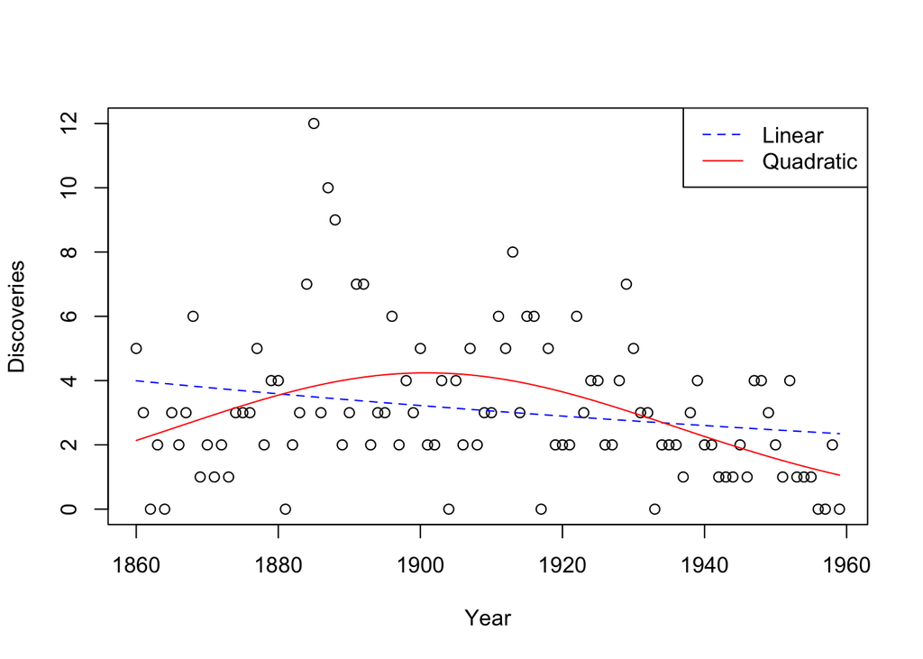

```r
x <- disc.df$year
plot(x, disc.df$disc, xlab = "Year", ylab = "Discoveries")
beta1 <- model1$coefficients
lines(x, exp(beta1[1] + beta1[2]*x), col="blue", lty=2)
beta2 <- model2$coefficients
lines(x, exp(beta2[1] + beta2[2]*x + beta2[3]*x^2), col="red")
legend("topright", c("Linear",  "Quadratic"), col=c("blue", "red"), lty=c(2,1))
```

**📈 Plotting it using ggplot2**

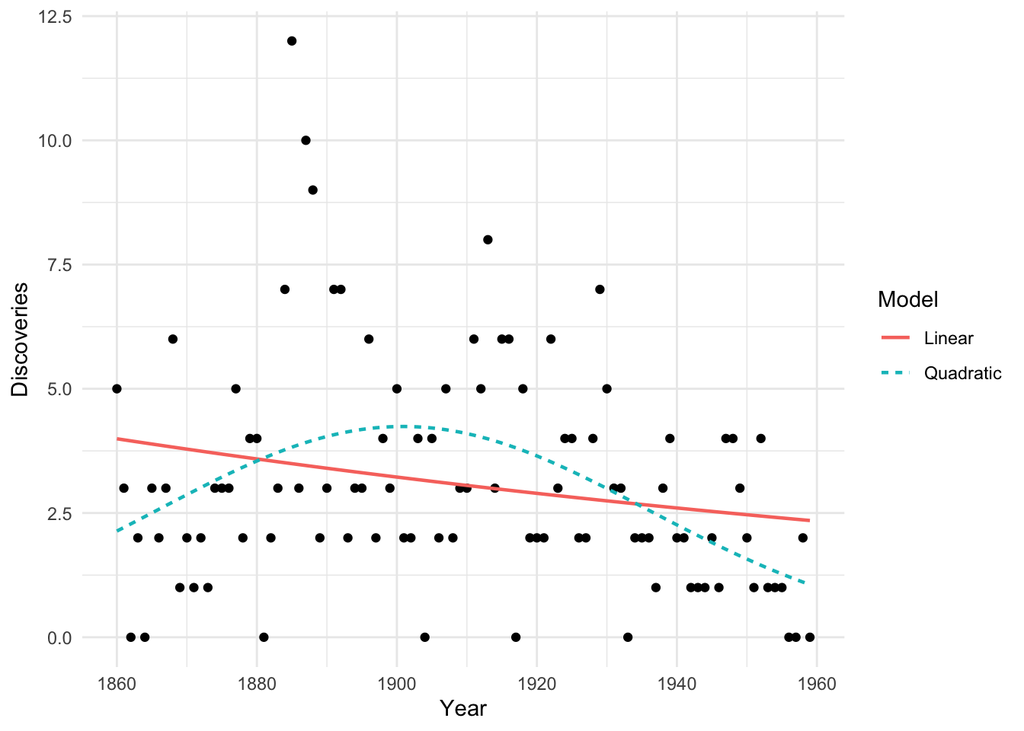

```r
library(ggplot2)
fitted_df <- rbind(
  data.frame(year=x, fitted=predict(model1, type="response"), model="Linear"),
  data.frame(year=x, fitted=predict(model2, type="response"), model="Quadratic"))
ggplot(disc.df, aes(year, as.numeric(disc))) +
  geom_point() +
  geom_line(data=fitted_df,
            aes(y=fitted, colour=model, linetype=model),
            linewidth=.8) +
  labs(x="Year",
       y="Discoveries",
       colour="Model",
       linetype="Model") +
  theme_minimal()
```

We will use deviance differences to perform likelihood ratio tests. From the above, the null model has deviance $164.68$, the model with just year has deviance $157.32$, and the model with year and year squared has deviance $132.84$. We compare the null model with the model with year, and the model with year and year squared. We also compare the model with year with the model with year and year squared.

```r
pchisq(164.68-157.32, 1, lower.tail=FALSE)
```

```
[1] 0.006669079
```

```r
pchisq(164.68-132.84, 2, lower.tail=FALSE)
```

```
[1] 1.219079e-07
```

```r
pchisq(157.32-132.84, 1, lower.tail=FALSE)
```

```
[1] 7.508521e-07
```

There is strong evidence that year improves the model, and very strong evidence that year squared has something to add. We conclude that there is strong evidence that the discovery rate has changed over time.